# Time Series Modeling of U.S.-China Import, 1989-2019

We first graph both the monthly imports and the logged monthly imports vs. time.

**TREND** - Upward trend is visible. In the imports plot (blue line), imports seem to increase exponentially or by a constant multiplicative factor until the 2009 recession period (highlighted in orange) where it begins to flatten. In the log Imports plot (red line) log Imports seem to increase by a constant additive amount before flattening after the 2009 recession.

**VOLATILITY** - There is evidence of increasing volatility in the imports plot. For example, it is evident that imports tend to rise and drop more sharply after the 2009 recession period. This suggest a multiplicative model is preferred than an additive one.

**IMPACT OF ECONOMIC DOWNTURN** - Economic downturn tend to cause imports to drop, as is evident in the 2001 and 2009 contractions (the drop is less prominent in 1990 where imports from China is still very low compared to the following periods).

**OUTLIER** - The drop in imports in February of 2009 is likely an outlier.

```r
f <- file.choose("ChinaImports2.txt")
imports <- read.csv(f)
```

```r
imports <- imports %>% mutate (year_month = paste(Year,Month,sep="-"))
```

```r
# modified
cycle <- data.frame(from = c('1945-2','1948-11','1953-7','1957-8','1960-4','1969-12','1973-11','1980-1','1981-7','1990-7','2001-3','2007-12','2020-3'),
                    to = c('1945-10','1949-10','1954-5','1958-4','1961-2','1970-11','1975-3','1980-7','1982-11','1991-3','2001-11','2009-6','2020-4'))
```

[figure not shown]

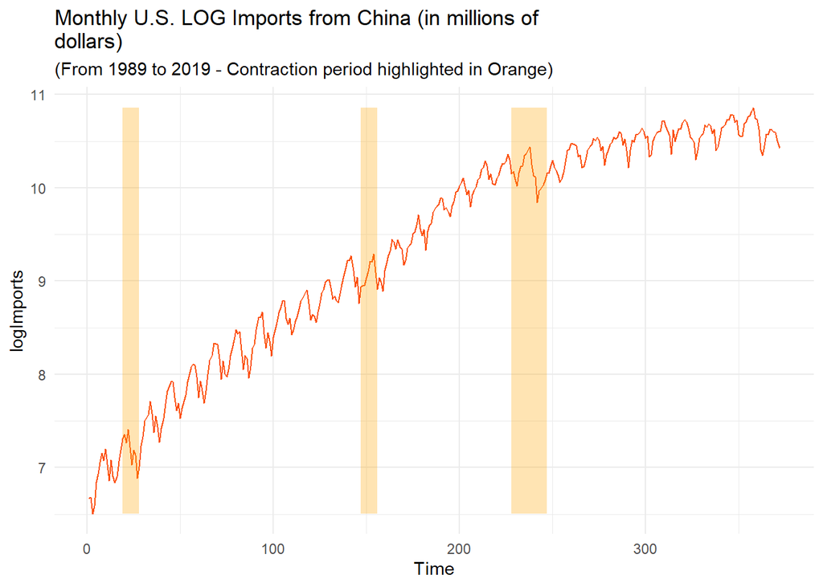

```r
ggplot(data=dat, aes(Time, logImports)) +
theme_minimal() +
geom_line(color = "#FC4E07", size = .5) +
geom_rect(data=rects, inherit.aes=FALSE, aes(xmin=start, xmax=end, ymin=min(dat$logImports),
ymax=max(dat$logImports), group=group), color="transparent", fill="orange",
alpha=0.3) +
labs(title = "Monthly U.S. LOG Imports from China (in millions of
dollars)", subtitle = "(From 1989 to 2019 - Contraction period highlighted in Orange)")
```

Fitting a regression model with seasonal and significant calendar components to the differences of the logged monthly imports.

```r
# add fMonth variables
imports <- imports %>% mutate(fMonth = as.factor(Month))
```

```r
# add differences column
logImports_lst <- imports$logImports
logDiff <- diff(logImports_lst,lag=1)

# insert NA to the beginning of the differences
logDiff <- c(NA, logDiff)

# combine to dataframe
imports$logDiff <- logDiff
```

```r
model1<-lm(logDiff~fMonth+c348+s348+c432+s432, data = imports);
```

```r
model2 <- lm(logDiff~fMonth+c348+s348, data = imports)
anova(model2, model1)
```

```
## Analysis of Variance Table
##
## Model 1: logDiff ~ fMonth + c348 + s348
## Model 2: logDiff ~ fMonth + c348 + s348 + c432 + s432
##   Res.Df    RSS Df Sum of Sq      F  Pr(>F)
## 1    357 1.5883
## 2    355 1.5667  2  0.021616 2.4491 0.08783 .
## ---
## Signif. codes:  0 '***' 0.001 '**' 0.01 '*' 0.05 '.' 0.1 ' ' 1
```

**Discussion:** The fitted model is a regression model with the differenced log imports of order 1 (logDiff) as y variable and fMonth dummy variables and calendar pairs 348 and 432 as X variables. The differenced log monthly imports column was created by using the diff() function on the logImports and adding ‘NA’ to the very first period in the data frame (Jan 1989) which does not have a corresponding differenced value.

The partial F-test shows that calendar pairs 432 has marginal significance of 0.087 but we include it in the regression model nevertheless.

More specifically, looking at final indices, since February has seasonal index of .87 we can expect sales to fall roughly 13 percent below the level of the trend. In March, imports on average increase to 3 percent below the level of trend (March has a seasonal index of .97). From April to October, imports increase and on average go above the level of trend as indicated by indices which exceed 1.00. In November and December they fall to roughly 10 and 13 percent below level of trend. In January imports rise to roughly 5 percent above trend level.

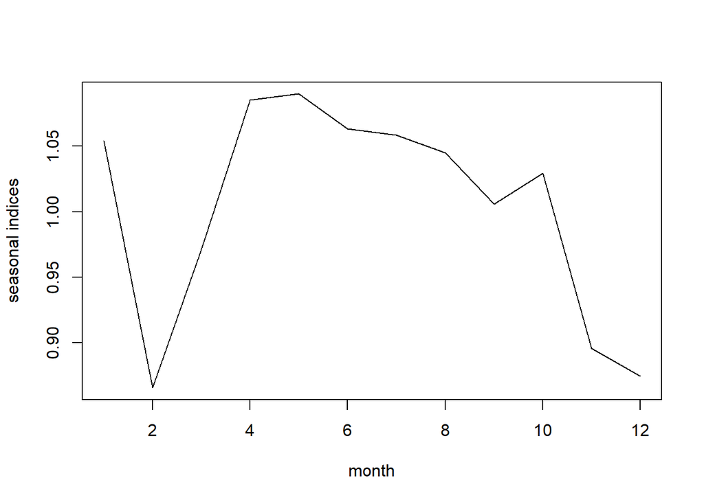

```r
b1<-coef(model1)[1]
b2<-coef(model1)[2:12]+b1
b3<-c(b1,b2)
seas<-b3-mean(b3)

seas.ts<-ts(exp(seas))
plot(seas.ts,ylab="seasonal indices",xlab="month")
```

```r
month <- seq(12)
seas_indices <- exp(seas)
seas_df <- data.frame(month, seas, seas_indices)
print.data.frame(tbl_df(seas_df))
```

```
##    month         seas seas_indices
## 1      1  0.052948420    1.0543753
## 2      2 -0.144305347    0.8656234
## 3      3 -0.029387793    0.9710398
## 4      4  0.081739214    1.0851728
## 5      5  0.086141128    1.0899601
## 6      6  0.061475925    1.0634049
## 7      7  0.056809263    1.0584539
## 8      8  0.044079249    1.0450652
## 9      9  0.005870053    1.0058873
## 10    10  0.029194210    1.0296245
## 11    11 -0.110288413    0.8955758
## 12    12 -0.134275909    0.8743488
```

Residual Analysis

**Discussion:**

**Residuals vs. Time Plot** - In the residuals vs. time plot, the flatness of the residuals indicate that trend has largely been captured. However, we do see that the model has not been reduced to white noise as we see bursts in certain periods.

**QQPLOT** - Most of the observations fall on or close to the normal line, though we do see that many are relatively further away from the line at the two tails. Not enough to conclude that the residuals are not normally distributed.

**PACF plot** - There are significant spikes in lags 1, 2, 10, and 25, which indicates uncaptured moving average structure in the data. We also see significant spikes at lags 12 and 36, which indicate that higher order moving average structure has not been captured.

**Spectral Density plot** - The spectral density plot shows uncaptured seasonality structure as indicated by the peaks at the seasonal frequencies (red lines). The plot also indicates that the model has not been reduced to white noise as the distance between the highest and lowest point is twice the upper half of the blue measurement line. The plot indicates, however, that trend has been captured as indicated by the low peak at the beginning of the plot.

```r
res1 <- resid(model1)
```

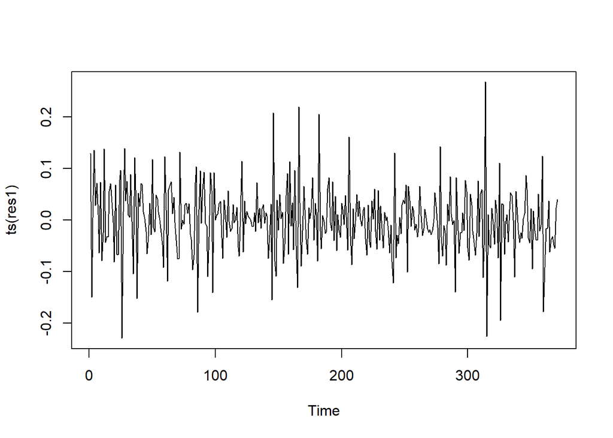

```r
plot(ts(res1))
```

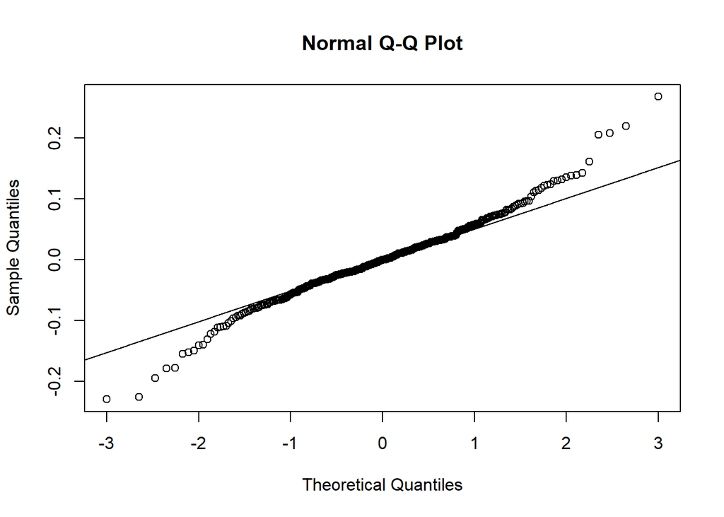

```r
qqnorm(res1)
qqline(res1)
```

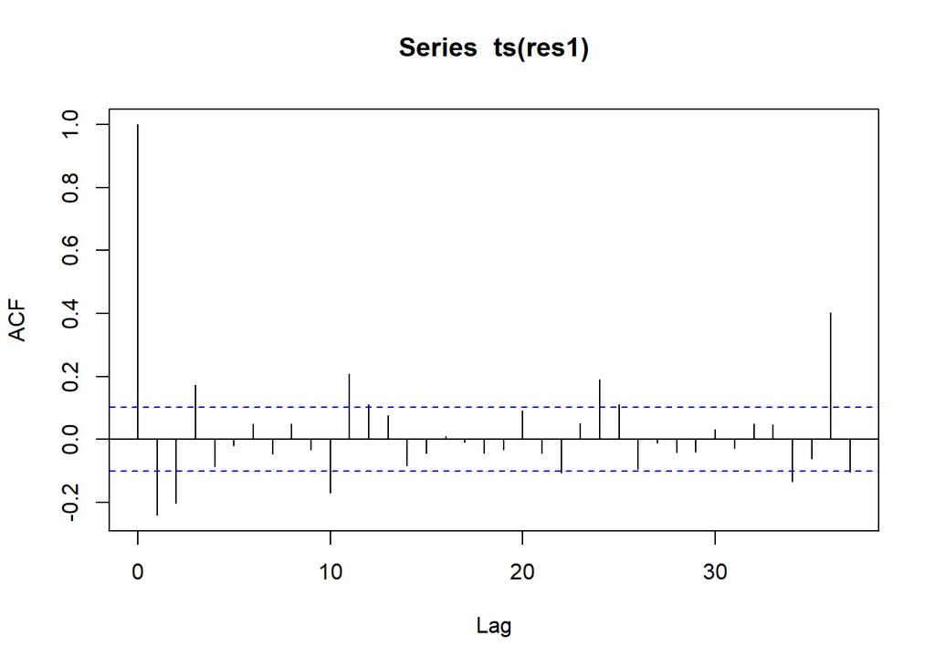

```r
acf(ts(res1), 37)
```

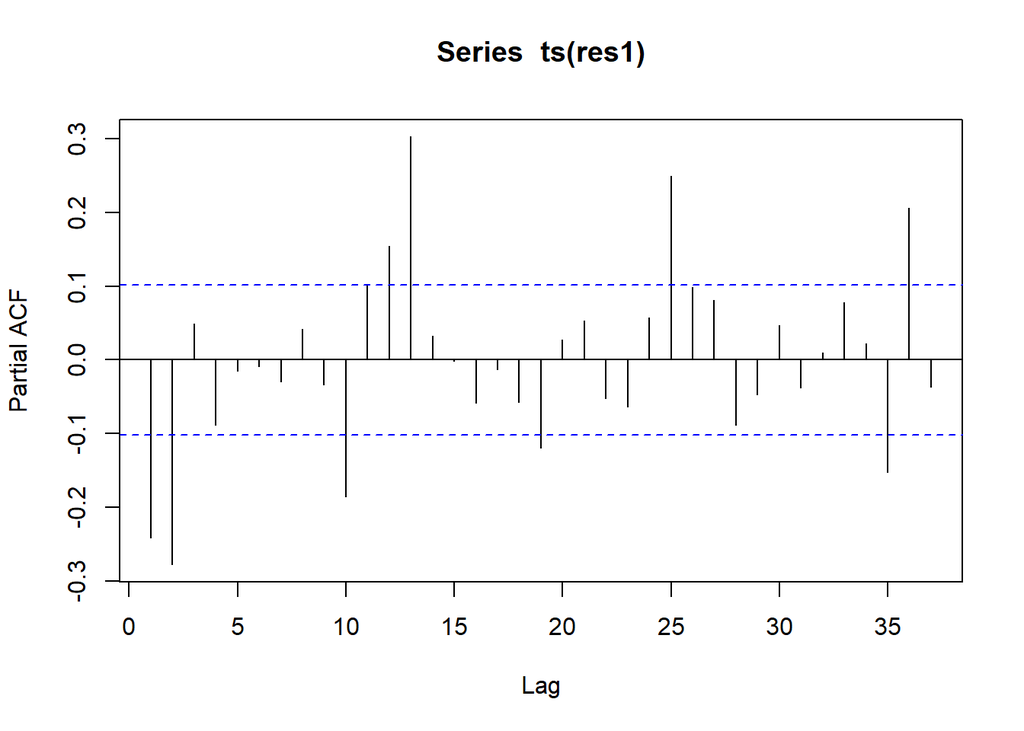

```r
pacf(ts(res1), 37)
```

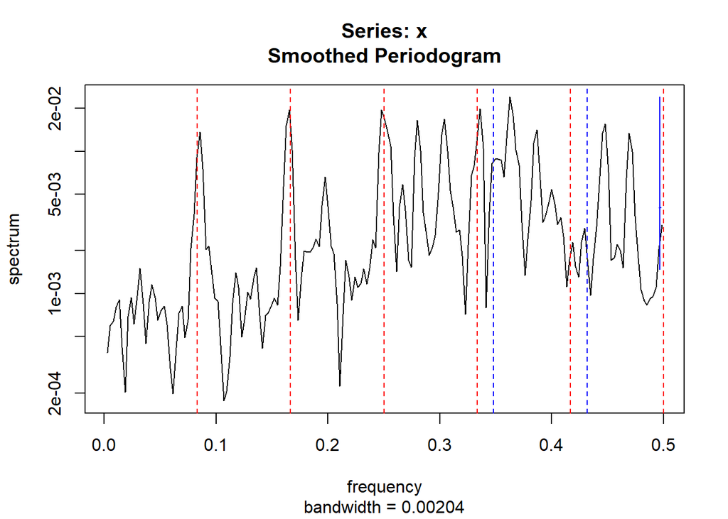

```r
spectrum(res1, span=3)
abline(v=c(1/12,2/12,3/12,4/12,5/12,6/12),col="red",lty=2)
abline(v=c(0.348,0.432),col="blue",lty=2)
```

```r
bartlettB.test(ts(res1))
```

```
##
##  Bartlett B Test for white noise
##
## data:
## = 3.1802, p-value = 3.285e-09
```

Fitting a regression model with just the calendar variables to the logged monthly imports series.

```r
model3 <- lm(logImports~c348+s348+c432+s432, data = imports)
```

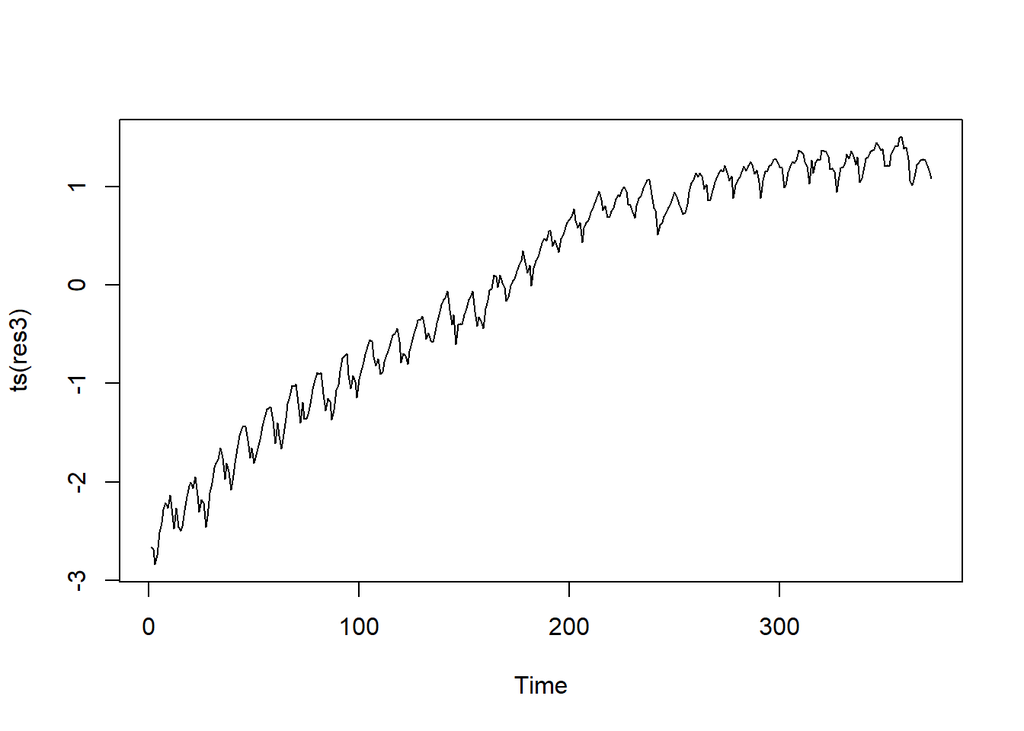

```r
res3 <- resid(model3)
plot(ts(res3))
```

Fitting a seasonal ARIMA model

**Discussion:** The first set of R-chunks below are for the initial analysis of where to start in terms of ARIMA structure. The following set of codes are fitting of different ARIMA models to see which one is best. The discussion on how we arrive at the final model follows in the next section. In this section we fit three ARIMA models and attempt to see which one is best based on AIC and residual analysis. The three ARIMA models are:

ARIMA(11,1,11)(1,1,1)12 ARIMA(0,1,11)(1,1,1)12 ARIMA(11,1,0)(1,1,1)12

```r
d1d12res3.ts<-ts(diff(diff(res3),12))
```

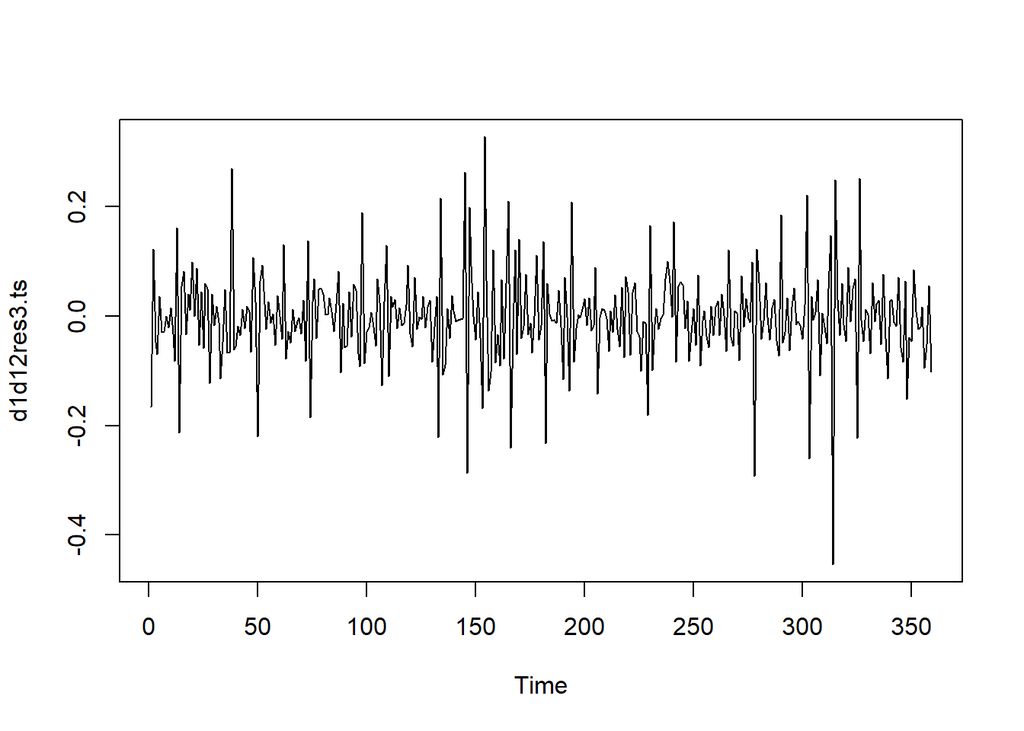

```r
plot(d1d12res3.ts)
```

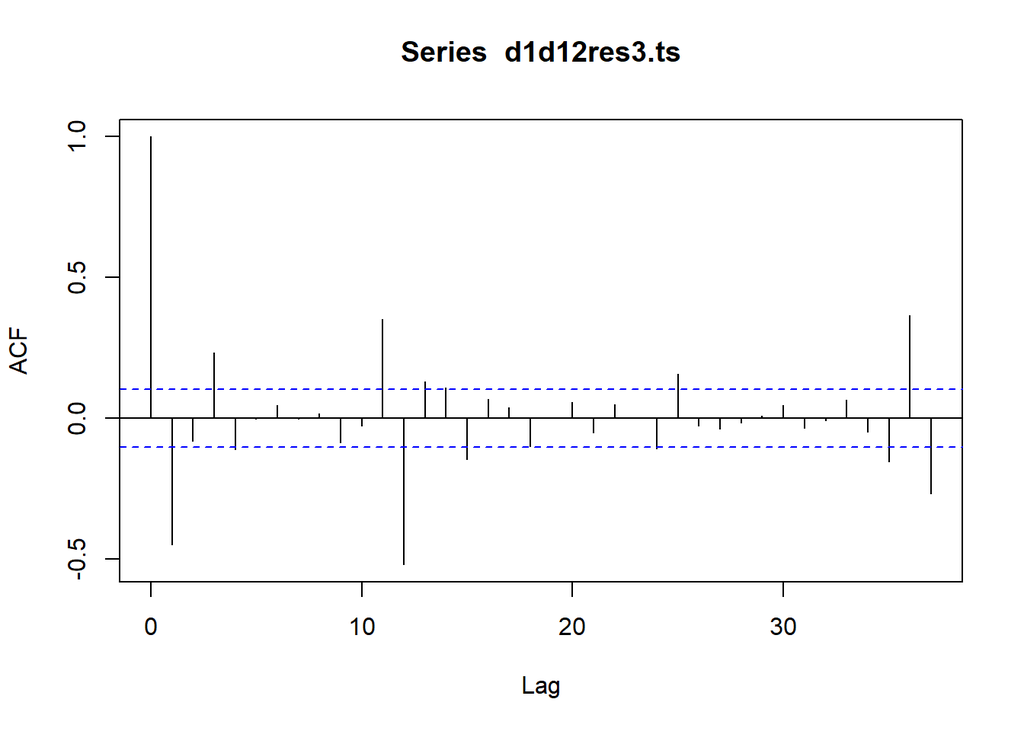

```r
acf(d1d12res3.ts, 37)
```

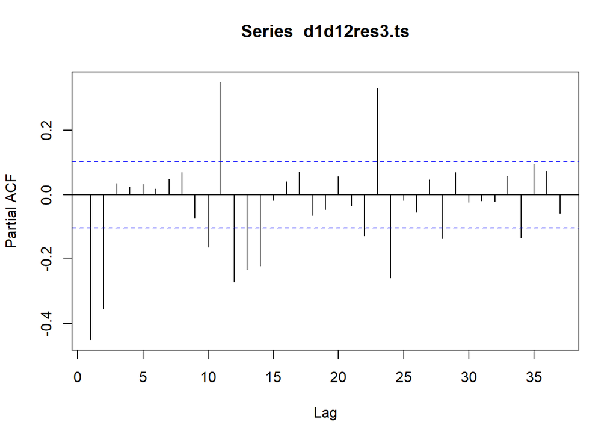

```r
pacf(d1d12res3.ts, 37)
```

**Fit and analysis of ARIMA(11,1,11)(1,1,1)12**

```r
res3.ts <- ts(res3)
model4<-arima(res3.ts,order=c(11,1,11),seasonal=list(order=c(1,1,1),period=12))
model4
```

```
##
## Call:
## arima(x = res3.ts, order = c(11, 1, 11), seasonal = list(order = c(1, 1, 1),
##     period = 12))
##
## Coefficients:
##           ar1      ar2      ar3      ar4      ar5      ar6      ar7      ar8
##       -0.9517  -0.6359  -0.3205  -0.3812  -0.2970  -0.4232  -0.6338  -0.9539
## s.e.   0.3827   0.5343   0.4464   0.2477   0.1976   0.1785   0.2447   0.3569
##           ar9     ar10    ar11     ma1     ma2     ma3     ma4     ma5     ma6
##       -0.5101  -0.0428  0.0305  0.5116  0.1628  0.1860  0.2663  0.1738  0.2764
## s.e.   0.5325   0.4128  0.1639  0.3785  0.3670  0.2091  0.1033  0.0921  0.0918
##         ma7     ma8     ma9     ma10    ma11     sar1     sma1
##       0.580  0.7731  0.0955  -0.2651  0.3201  -0.1419  -0.5994
## s.e.  0.156  0.2888  0.4189   0.2003  0.1370   0.0867   0.0705
##
## sigma^2 estimated as 0.002512:  log likelihood = 552.96,  aic = -1055.92
```

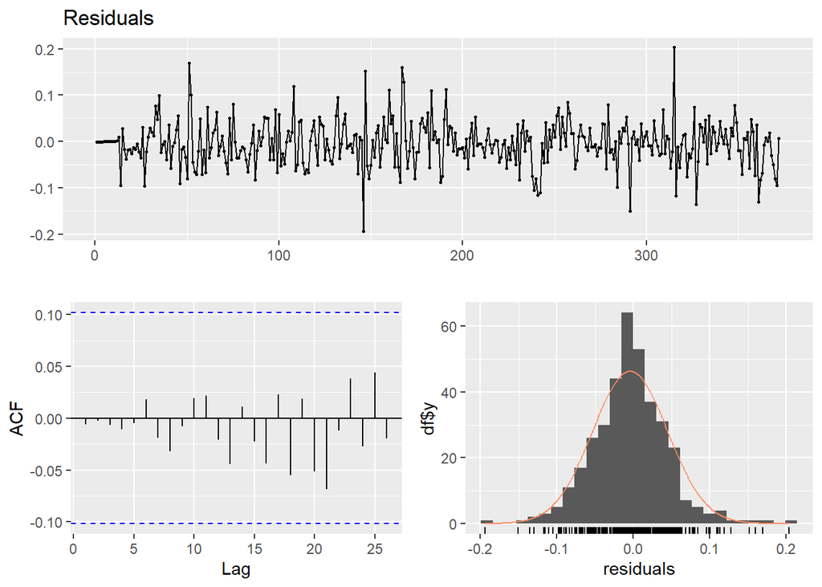

```
##
##  Ljung-Box test
##
## data:  Residuals
## Q* = 0.90559, df = 10, p-value = 0.9999
##
## Model df: 0.   Total lags used: 10
```

```r
checkresiduals(ts(resid(model4)))
```

```r
coeftest(model4)
```

```
##
## z test of coefficients:
##
##       Estimate Std. Error z value  Pr(>|z|)
## ar1  -0.951692   0.382652 -2.4871 0.0128790 *
## ar2  -0.635916   0.534336 -1.1901 0.2340053
## ar3  -0.320506   0.446419 -0.7179 0.4727883
## ar4  -0.381228   0.247734 -1.5389 0.1238382
## ar5  -0.296997   0.197574 -1.5032 0.1327830
## ar6  -0.423203   0.178461 -2.3714 0.0177208 *
## ar7  -0.633795   0.244658 -2.5905 0.0095828 **
## ar8  -0.953851   0.356914 -2.6725 0.0075289 **
## ar9  -0.510134   0.532520 -0.9580 0.3380817
## ar10 -0.042823   0.412785 -0.1037 0.9173743
## ar11  0.030485   0.163878  0.1860 0.8524254
## ma1   0.511608   0.378514  1.3516 0.1764967
## ma2   0.162770   0.366978  0.4435 0.6573734
## ma3   0.186018   0.209088  0.8897 0.3736465
## ma4   0.266256   0.103281  2.5780 0.0099379 **
## ma5   0.173752   0.092129  1.8860 0.0592990 .
## ma6   0.276446   0.091805  3.0112 0.0026018 **
## ma7   0.579975   0.155982  3.7182 0.0002006 ***
## ma8   0.773097   0.288827  2.6767 0.0074357 **
## ma9   0.095522   0.418855  0.2281 0.8196028
## ma10 -0.265081   0.200315 -1.3233 0.1857279
## ma11  0.320119   0.137009  2.3365 0.0194657 *
## sar1 -0.141855   0.086695 -1.6363 0.1017854
## sma1 -0.599390   0.070450 -8.5080 < 2.2e-16 ***
## ---
## Signif. codes:  0 '***' 0.001 '**' 0.01 '*' 0.05 '.' 0.1 ' ' 1
```

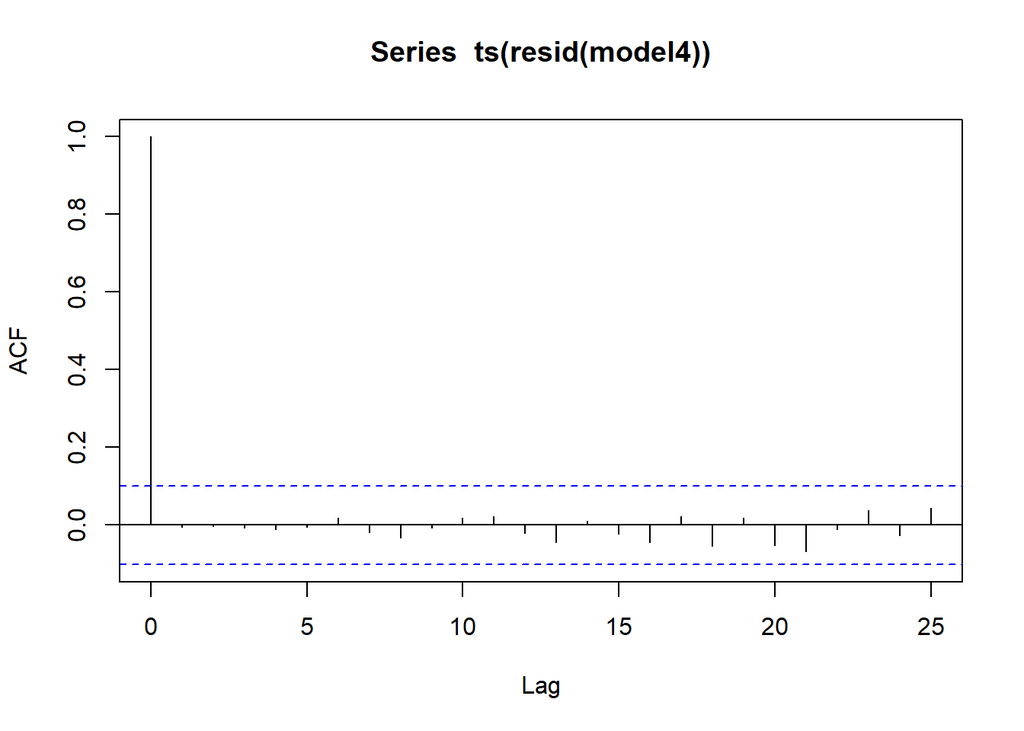

```r
acf(ts(resid(model4)))
```

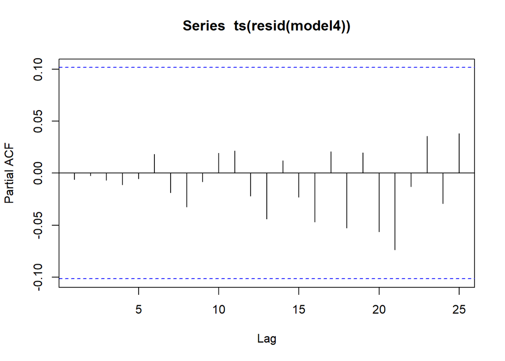

```r
pacf(ts(resid(model4)))
```

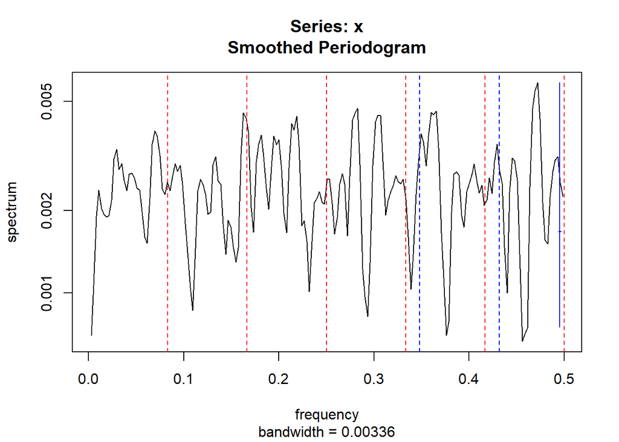

```r
spectrum(resid(model4), span=5)
abline(v=c(1/12,2/12,3/12,4/12,5/12,6/12),col="red",lty=2)
abline(v=c(0.348,0.432),col="blue",lty=2)
```

```r
bartlettB.test(ts(resid(model4)))
```

```
##
##  Bartlett B Test for white noise
##
## data:
## = 0.30137, p-value = 1
```

**Fit and analysis of ARIMA(0,1,11)(1,1,1)12**

```r
model5<-arima(res3.ts,order=c(0,1,11),seasonal=list(order=c(1,1,1),period=12))
model5
```

```
##
## Call:
## arima(x = res3.ts, order = c(0, 1, 11), seasonal = list(order = c(1, 1, 1),
##     period = 12))
##
## Coefficients:
##           ma1      ma2     ma3      ma4     ma5     ma6     ma7      ma8
##       -0.4461  -0.0608  0.2397  -0.1616  0.0665  0.0150  0.0725  -0.0736
## s.e.   0.0536   0.0572  0.0570   0.0594  0.0603  0.0659  0.0609   0.0538
##           ma9     ma10    ma11     sar1     sma1
##       -0.0013  -0.0085  0.2324  -0.2815  -0.6704
## s.e.   0.0651   0.0585  0.0564   0.0672   0.0456
##
## sigma^2 estimated as 0.002839:  log likelihood = 537.38,  aic = -1046.76
```

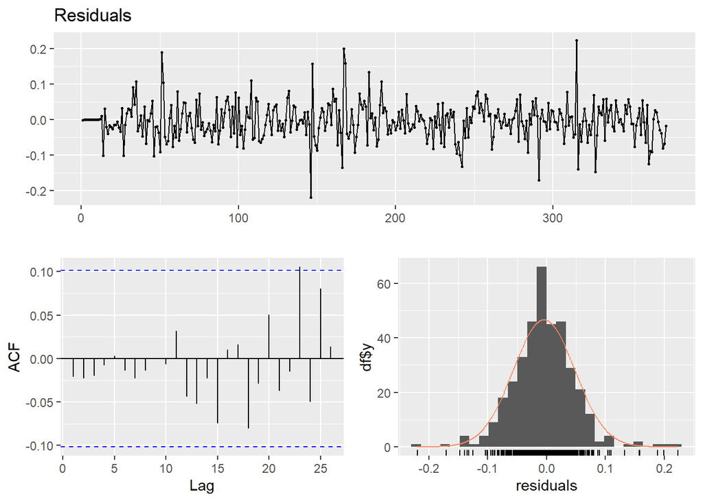

```
##
##  Ljung-Box test
##
## data:  Residuals
## Q* = 0.88992, df = 10, p-value = 0.9999
##
## Model df: 0.   Total lags used: 10
```

```r
checkresiduals(ts(resid(model5)))
```

```r
coeftest(model5)
```

```
##
## z test of coefficients:
##
##        Estimate Std. Error  z value  Pr(>|z|)
## ma1  -0.4461310  0.0535763  -8.3270 < 2.2e-16 ***
## ma2  -0.0607736  0.0572027  -1.0624  0.288042
## ma3   0.2396881  0.0570122   4.2042 2.621e-05 ***
## ma4  -0.1616336  0.0593534  -2.7232  0.006464 **
## ma5   0.0665166  0.0602881   1.1033  0.269892
## ma6   0.0150491  0.0659029   0.2284  0.819372
## ma7   0.0724682  0.0609097   1.1898  0.234139
## ma8  -0.0736183  0.0538176  -1.3679  0.171336
## ma9  -0.0012769  0.0650554  -0.0196  0.984340
## ma10 -0.0084839  0.0584674  -0.1451  0.884629
## ma11  0.2323652  0.0564483   4.1164 3.848e-05 ***
## sar1 -0.2815049  0.0671707  -4.1909 2.779e-05 ***
## sma1 -0.6704438  0.0455845 -14.7077 < 2.2e-16 ***
## ---
## Signif. codes:  0 '***' 0.001 '**' 0.01 '*' 0.05 '.' 0.1 ' ' 1
```

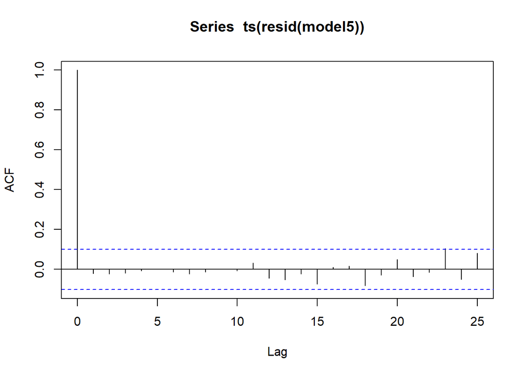

```r
acf(ts(resid(model5)))
```

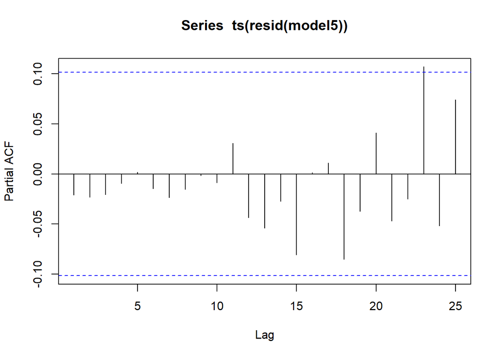

```r
pacf(ts(resid(model5)))
```

```r
bartlettB.test(ts(resid(model5)))
```

```
##
##  Bartlett B Test for white noise
##
## data:
## = 0.48505, p-value = 0.9727
```

**Fit and analysis of ARIMA(11,1,0)(1,1,1)12**

```r
model6<-arima(res3.ts,order=c(11,1,0),seasonal=list(order=c(1,1,1),period=12))
model6
```

```
##
## Call:
## arima(x = res3.ts, order = c(11, 1, 0), seasonal = list(order = c(1, 1, 1),
##     period = 12))
##
## Coefficients:
##           ar1      ar2     ar3      ar4     ar5     ar6     ar7      ar8
##       -0.4750  -0.2770  0.0467  -0.0405  0.0383  0.0129  0.0687  -0.0270
## s.e.   0.0533   0.0577  0.0601   0.0608  0.0603  0.0610  0.0606   0.0602
##           ar9     ar10   ar11     sar1     sma1
##       -0.0108  -0.0388  0.200  -0.1482  -0.6319
## s.e.   0.0601   0.0597  0.055   0.0725   0.0528
##
## sigma^2 estimated as 0.002864:  log likelihood = 536.09,  aic = -1044.17
```

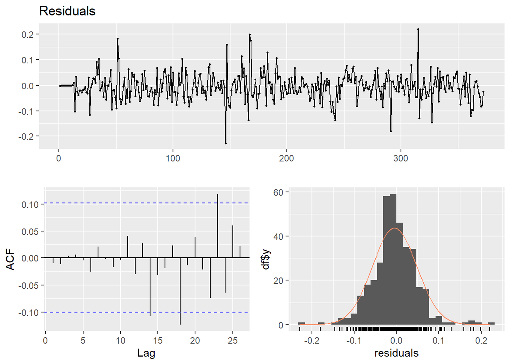

```
##
##  Ljung-Box test
##
## data:  Residuals
## Q* = 0.64857, df = 10, p-value = 1
##
## Model df: 0.   Total lags used: 10
```

```r
checkresiduals(ts(resid(model6)))
```

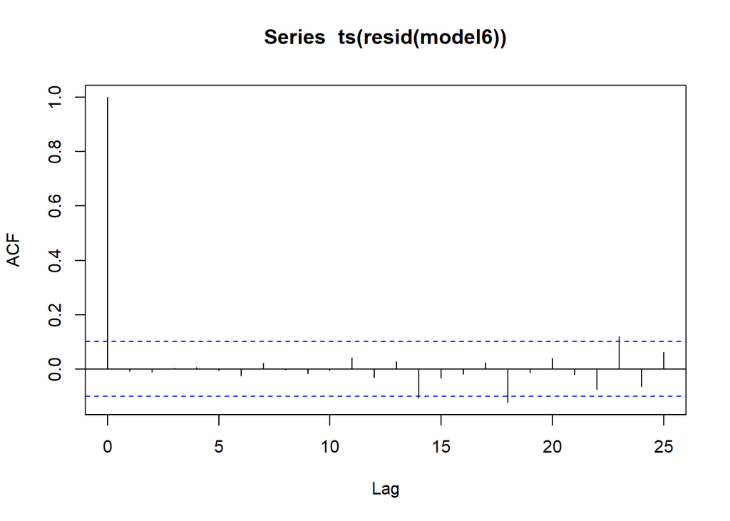

```r
acf(ts(resid(model6)))
```

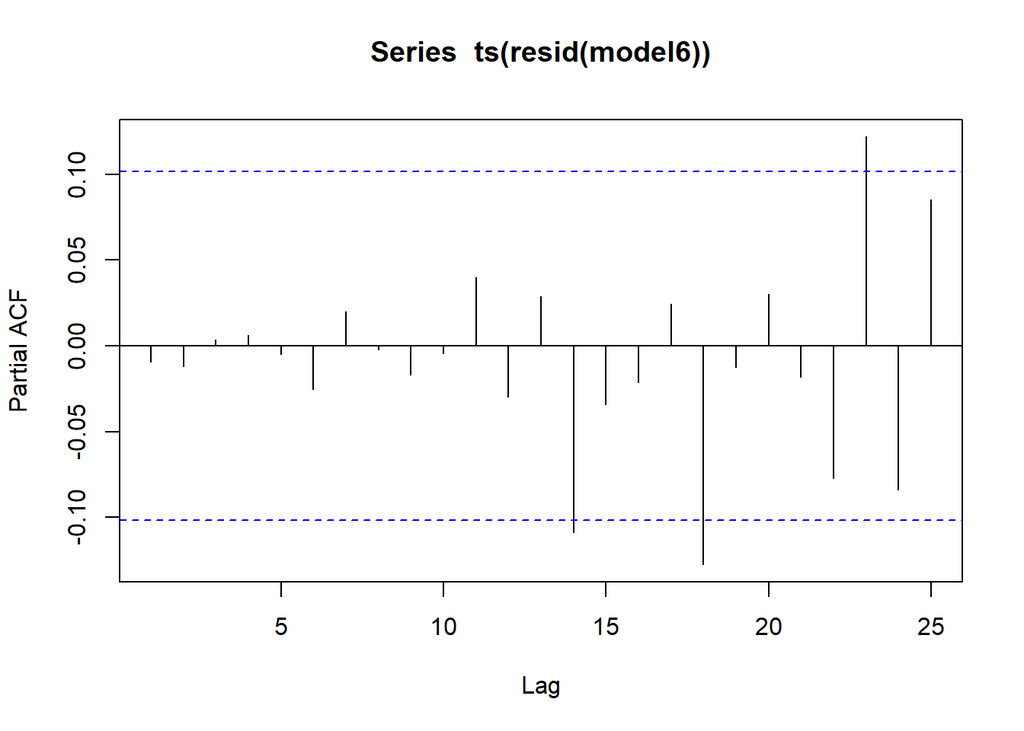

```r
pacf(ts(resid(model6)))
```

```r
bartlettB.test(ts(resid(model6)))
```

```
##
##  Bartlett B Test for white noise
##
## data:
## = 0.40032, p-value = 0.9972
```

**Discussion:** As we see both seasonality and trend in the plot of the residuals from part(a), we difference the residuals using orders 1 and 12. We store the differenced residuals in d1d12res3.ts, and use the time series data to create ACF and PACF plots. We analyze the two plots to determine a good place to start in fitting our model.

In our ACF plot we see significant spikes at lags 1, 3 and 11, as well as lags 12, 24, 36 suggesting that an ARIMA(0,1,11)(0,1,1)12 may be a good place to start.

Looking at the PACF plot, we see significant spikes at lags 1, 2 and 11, as well as lags 12 and 24, suggesting that ARIMA(11,1,0)(1,1,0)12 may also be a good candidate.

We test fitting a third model with structure of ARIMA(11,1,11)(1,1,1)12 and see that the model has even better residuals results with no autocorrelation structure remaining visible in the ACF/PACF plot. There is a concern for overfitting, but the model yields an AIC score of -1055.92, which suggests that it is not an overfit model despite the increased number of variables.

We select the ARIMA(11,1,11)(1,1,1)12 as our final model. The model has an AIC of -1055.92, the best from the three models which we originally fit. It has 11 AR and 11 MA variables in the trend component and 1 AR and 1 MA variable in the seasonal component of the ARIMA model. The order of differencing is 1 for trend and 1 for seasonality.

Comparing the static estimates to those obtained via regression.

**Discussion:**

**STATIC ESTIMATES**

**DYNAMIC ESTIMATES**

**STATIC ESTIMATES TABLE AND PLOT**

```r
sel<-1:12
arimapred<-resid(model3)[-sel]-resid(model4)[-sel]
```

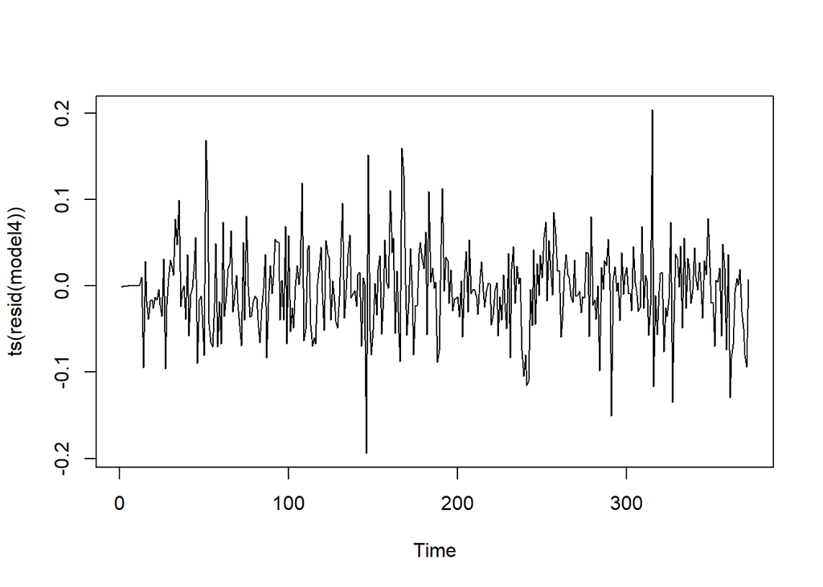

```r
plot(ts(resid(model4)))
```

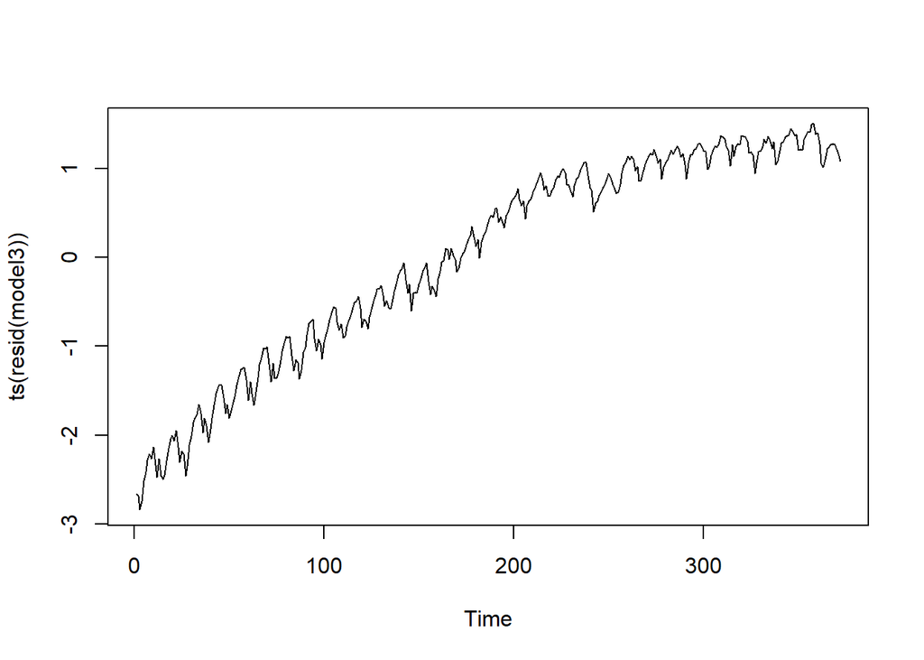

```r
plot(ts(resid(model3)))
```

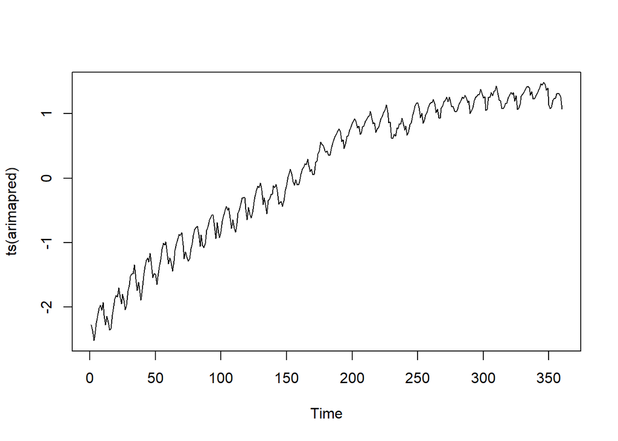

```r
plot(ts(arimapred))
```

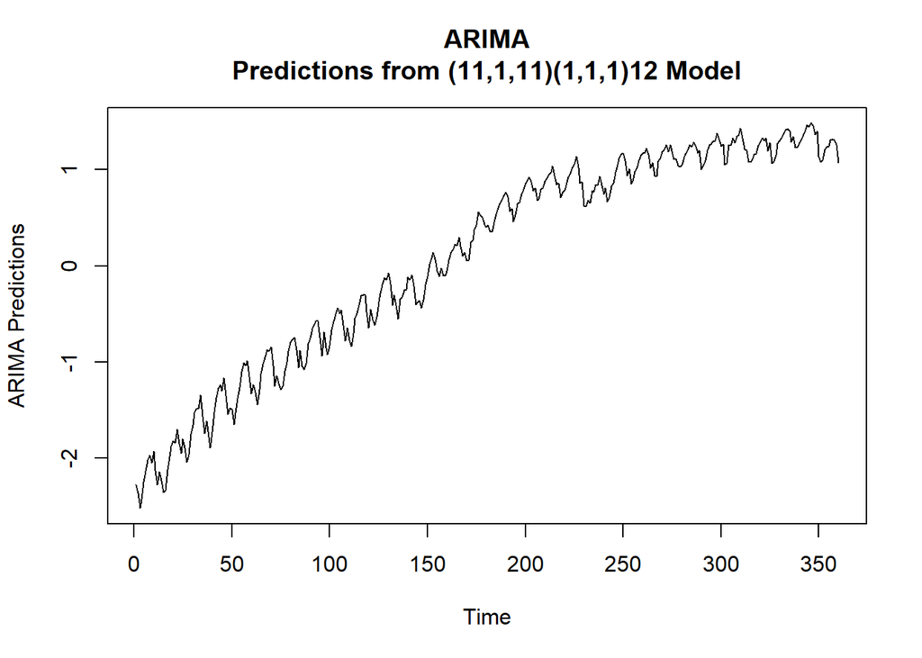

```r
arimapred.ts<-ts(arimapred)
plot(arimapred.ts,xlab="Time",ylab="ARIMA Predictions",main="ARIMA
Predictions from (11,1,11)(1,1,1)12 Model")
```

```r
# we do see trend remaining so we attempt to remove trend using differencing
model7 <- arima(arimapred.ts,order=c(0,1,0),seasonal=list(order=c(0,0,0),period=12))
arimapred2<- resid(model7)
```

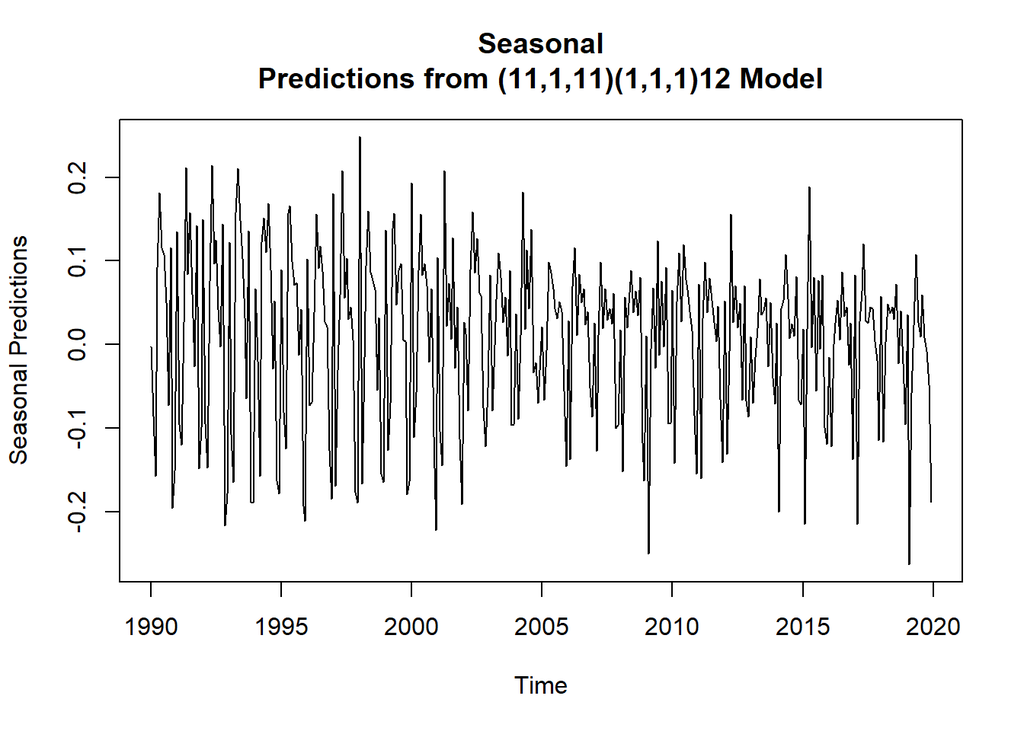

```r
arimapred2.ts<-ts(arimapred2,start=c(1990,1),freq=12)
plot(arimapred2.ts,xlab="Time",ylab="Seasonal Predictions",main="Seasonal
Predictions from (11,1,11)(1,1,1)12 Model")
```

```r
monmeans<-tapply(arimapred2,imports$Month[-sel],mean)
seas2<-monmeans-mean(monmeans)
seas2_indices <- exp(seas2)
```

**TABLE OF SEASONAL INDICES FROM REGRESSION AND ARIMA**

```r
cbind(1:12,seas_indices,seas2_indices)
```

```
##                seas_indices seas2_indices
## (Intercept)  1    1.0543753     1.0653679
## fMonth2      2    0.8656234     0.8743448
## fMonth3      3    0.9710398     0.9532092
## fMonth4      4    1.0851728     1.0866580
## fMonth5      5    1.0899601     1.0954019
## fMonth6      6    1.0634049     1.0714782
## fMonth7      7    1.0584539     1.0543450
## fMonth8      8    1.0450652     1.0545681
## fMonth9      9    1.0058873     0.9888709
## fMonth10    10    1.0296245     1.0405851
## fMonth11    11    0.8955758     0.8919001
## fMonth12    12    0.8743488     0.8653442
```

**PLOT OF SEASONAL INDICES FROM REGRESSION AND ARIMA**

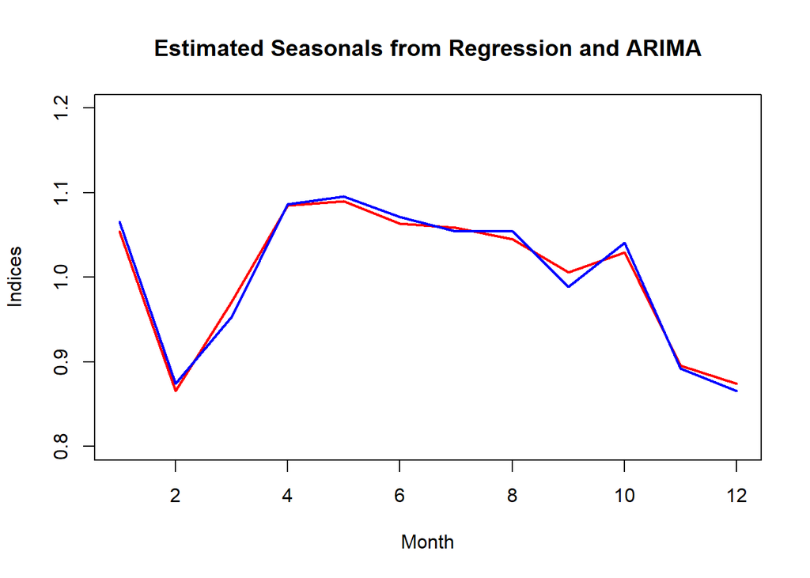

```r
plot(ts(seas_indices),xlab="Month",ylab="Estimated Seasonal
Indices",main="Estimated Seasonals from Regression and ARIMA",ylim=c(0.8,1.2),lty=1,lwd=2,col="red")
lines(ts(seas2_indices),lty=1,lwd=2,col="blue")
```